```python
import pandas as pd
import numpy as np
import matplotlib.pyplot as plt

from scipy.stats import gaussian_kde, norm

np.random.seed(101)
```

# Zadanie 1

Wygeneruj próbkę z rozkładu dwumianowego (p = 0,4) Wygeneruj próbkę z rozkładu geometrycznego p=0.4 Oblicz sumę tych zmiennych i przedstaw empiryczny rozkład.

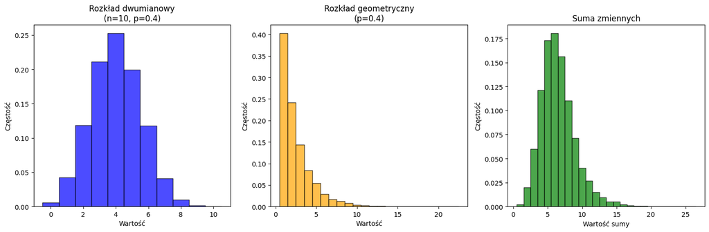

```python
binomial_sample = np.random.binomial(n=10, p=0.4, size=10000)
geometric_sample = np.random.geometric(p=0.4, size=10000)
sum_sample = binomial_sample + geometric_sample

fig, axes = plt.subplots(1, 3, figsize=(15, 5))
bins_binom = np.arange(binomial_sample.min() - 0.5, binomial_sample.max() + 1.5, 1)
bins_geom = np.arange(geometric_sample.min() - 0.5, geometric_sample.max() + 1.5, 1)
bins_sum = np.arange(sum_sample.min() - 0.5, sum_sample.max() + 1.5, 1)

axes[0].hist(binomial_sample, bins=bins_binom, density=True, alpha=0.7, color='blue', edgecolor='black')
axes[0].set_title('Rozkład dwumianowy\n(n=10, p=0.4)')
axes[0].set_xlabel('Wartość')
axes[0].set_ylabel('Częstość')

axes[1].hist(geometric_sample, bins=bins_geom, density=True, alpha=0.7, color='orange', edgecolor='black')
axes[1].set_title('Rozkład geometryczny\n(p=0.4)')
axes[1].set_xlabel('Wartość')
axes[1].set_ylabel('Częstość')

axes[2].hist(sum_sample, bins=bins_sum, density=True, alpha=0.7, color='green', edgecolor='black')
axes[2].set_title('Suma zmiennych')
axes[2].set_xlabel('Wartość sumy')
axes[2].set_ylabel('Częstość')

plt.tight_layout()
```

# Zadanie 2

Zbadać rozkład sumy zmiennej losowej N(0,1) i wykładniczego Exp(λ=1). Wygeneruj 10,000 wartości z N(0,1) i Exp(1). Oblicz ich sumę. Przedstaw histogram i porównaj go z przybliżonym rozkładem (analiza kształtu).

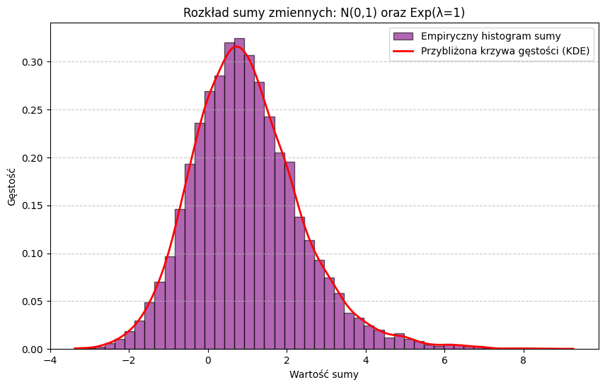

```python
n_sample = np.random.normal(loc=0.0, scale=1.0, size=10000)
exp_sample = np.random.exponential(scale=1.0, size=10000)

sum_sample = n_sample + exp_sample

plt.figure(figsize=(10, 6))

plt.hist(sum_sample, bins=50, density=True, alpha=0.6, color='purple', edgecolor='black',
         label='Empiryczny histogram sumy')

kde = gaussian_kde(sum_sample)
x_vals = np.linspace(sum_sample.min(), sum_sample.max(), 500)
plt.plot(x_vals, kde(x_vals), color='red', lw=2, label='Przybliżona krzywa gęstości (KDE)')

plt.title('Rozkład sumy zmiennych: N(0,1) oraz Exp(λ=1)')
plt.xlabel('Wartość sumy')
plt.ylabel('Gęstość')
plt.legend()
plt.grid(axis='y', linestyle='--', alpha=0.7)
```

Po dodaniu do siebie rozkładu normalnego i rozkładu wykładniczego otrzymaliśmy asymetryczny kształt, tworząc rozkład prawoskośny. Lewa część wykresu nadal przypomina klasyczny rozkład normalny, ale z prawej strony utworzył się powoli opadający ogon.

# Zadanie 3

Zbadać przybliżenie rozkładu dwumianowego przez Poissona dla małego p, dużego n. Wygeneruj próbki z Bin(n=1000, p=0.005). Wygeneruj próbki z Poisson(λ=5), gdzie λ ≈ np. Porównaj histogramy

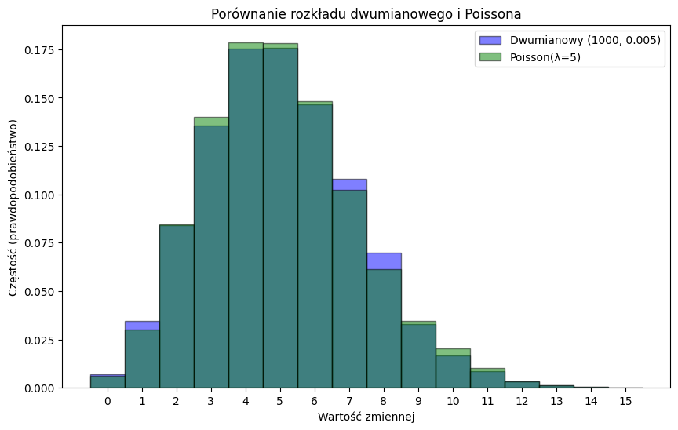

```python
n = 1000
p = 0.005
lam = n * p
rozmiar_probki = 10000

binom_sample = np.random.binomial(n=n, p=p, size=rozmiar_probki)
poisson_sample = np.random.poisson(lam=lam, size=rozmiar_probki)
plt.figure(figsize=(10, 6))

min_val = min(binom_sample.min(), poisson_sample.min())
max_val = max(binom_sample.max(), poisson_sample.max())
bins = np.arange(min_val - 0.5, max_val + 1.5, 1)

plt.hist(binom_sample, bins=bins, density=True, alpha=0.5, color='blue', edgecolor='black',
         label='Dwumianowy (1000, 0.005)')
plt.hist(poisson_sample, bins=bins, density=True, alpha=0.5, color='green', edgecolor='black',
         label='Poisson(λ=5)')

plt.title('Porównanie rozkładu dwumianowego i Poissona')
plt.xlabel('Wartość zmiennej')
plt.ylabel('Częstość (prawdopodobieństwo)')
plt.xticks(np.arange(min_val, max_val + 1, 1))
plt.legend()
```

Oba rozkłady są bardzo podobne, co potwierdza, że dla małego p i dużego n, rozkład dwumianowy można dobrze przybliżyć rozkładem Poissona. Histogramy nakładają się na siebie, a kształt obu rozkładów jest niemal identyczny.

# Zadanie 4

1. Wygeneruj 10,000 próbek z rozkładu dwumianowego Bin(n = 1000, p = 0.5).
2. Na podstawie tych próbek oblicz średnią i odchylenie standardowe.
3. Narysuj histogram rozkładu oraz przybliżoną funkcję gęstości normalną N (500, 15.81).
4. Porównaj rozkład empiryczny z rozkładem normalnym.

```
Średnia empiryczna: 499.97
Średnia teoretyczna: 500.00
Odchylenie standardowe empiryczne: 15.72
Odchylenie standardowe teoretyczne: 15.81
```

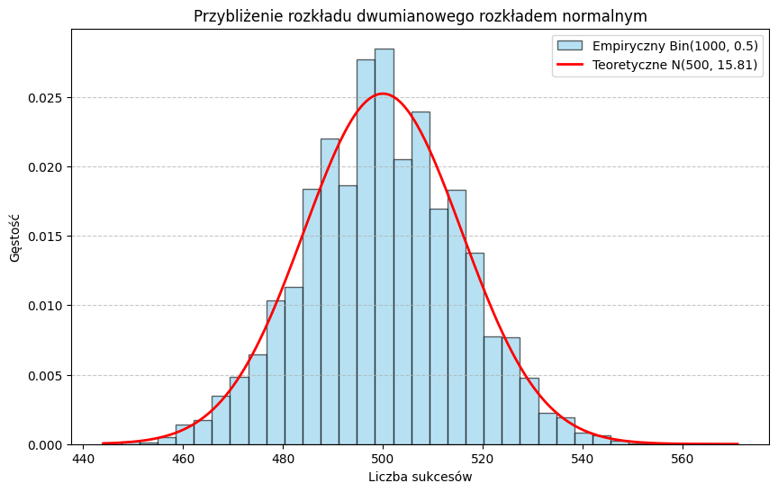

```python
n = 1000
p = 0.5
size = 10000
binom_samples = np.random.binomial(n=n, p=p, size=size)

emp_mean = np.mean(binom_samples)
emp_std = np.std(binom_samples)

theo_mean = n * p
theo_std = np.sqrt(n * p * (1 - p))

print(f'Średnia empiryczna: {emp_mean:.2f}')
print(f'Średnia teoretyczna: {theo_mean:.2f}')
print(f'Odchylenie standardowe empiryczne: {emp_std:.2f}')
print(f'Odchylenie standardowe teoretyczne: {theo_std:.2f}')

plt.figure(figsize=(10, 6))
plt.hist(binom_samples, bins=35, density=True, alpha=0.6, color='skyblue', edgecolor='black',
         label='Empiryczny Bin(1000, 0.5)')
x_vals = np.linspace(binom_samples.min(), binom_samples.max(), 500)
pdf_vals = norm.pdf(x_vals, loc=500, scale=15.81)
plt.plot(x_vals, pdf_vals, color='red', lw=2, label='Teoretyczne N(500, 15.81)')
plt.title('Przybliżenie rozkładu dwumianowego rozkładem normalnym')
plt.xlabel('Liczba sukcesów')
plt.ylabel('Gęstość')
plt.legend()
plt.grid(axis='y', linestyle='--', alpha=0.7)
```

# Zadanie 5

Wykorzystując centralne twierdzenie graniczne dla sum pokaż dla rozkładu chi^2 o 2 stopniach swobody jak wygląda suma n niezależnych zmiennych losowych. Pokaż jak zmienia się histogram i czy rzeczywiście rozkład ten dąży do rozkładu normalnego. Sprawdź czy średnia i odchylenie z nowego rozkładu pokrywa się z teoretycznym.

```
n=1:
Średnia empiryczna: 2.00, Średnia teoretyczna: 2.00
Odchylenie empiryczne: 1.97, Odchylenie teoretyczne: 2.00

n=5:
Średnia empiryczna: 9.95, Średnia teoretyczna: 10.00
Odchylenie empiryczne: 4.40, Odchylenie teoretyczne: 4.47

n=20:
Średnia empiryczna: 39.88, Średnia teoretyczna: 40.00
Odchylenie empiryczne: 8.89, Odchylenie teoretyczne: 8.94

n=100:
Średnia empiryczna: 199.63, Średnia teoretyczna: 200.00
Odchylenie empiryczne: 20.14, Odchylenie teoretyczne: 20.00
```

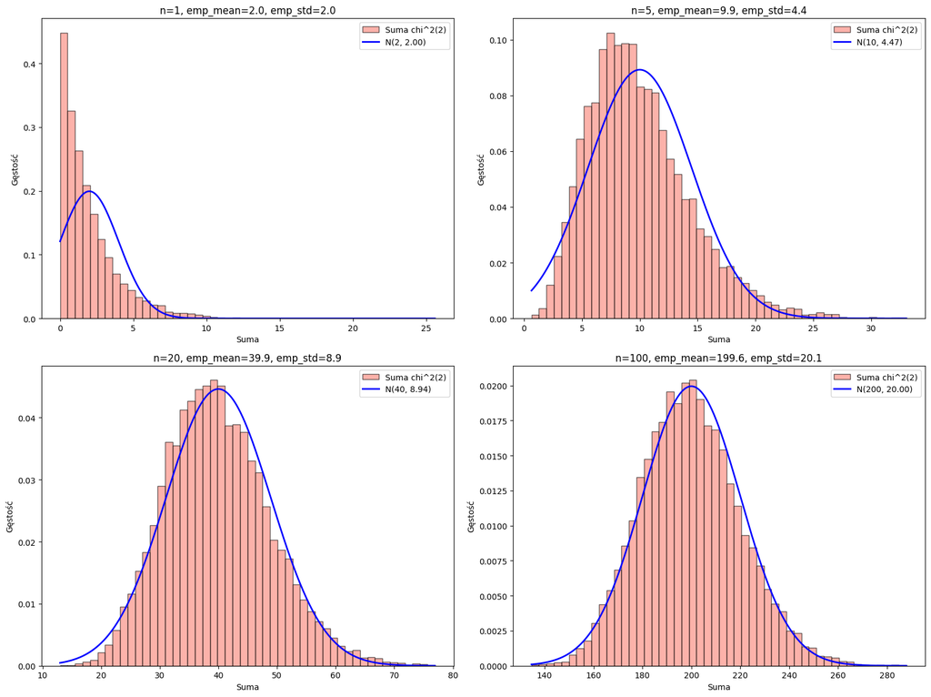

```python
df = 2
num_sim = 10000
n_values = [1, 5, 20, 100]

plt.figure(figsize=(16, 12))

for i, n in enumerate(n_values, 1):
    chi2_samples = np.random.chisquare(df=df, size=(n, num_sim))
    sum_chi2 = np.sum(chi2_samples, axis=0)

    emp_mean = np.mean(sum_chi2)
    emp_std = np.std(sum_chi2)

    theo_mean = n * df
    theo_std = np.sqrt(2 * n * df)

    print(f'n={n}:')
    print(f'Średnia empiryczna: {emp_mean:.2f}, Średnia teoretyczna: {theo_mean:.2f}')
    print(f'Odchylenie empiryczne: {emp_std:.2f}, Odchylenie teoretyczne: {theo_std:.2f}\n')

    plt.subplot(2, 2, i)
    plt.hist(sum_chi2, bins=50, density=True, alpha=0.6, color='salmon', edgecolor='black', label=f'Suma chi^2({df})')

    x_vals = np.linspace(sum_chi2.min(), sum_chi2.max(), 500)
    pdf_vals = norm.pdf(x_vals, loc=theo_mean, scale=theo_std)
    plt.plot(x_vals, pdf_vals, color='blue', lw=2, label=f'N({theo_mean}, {theo_std:.2f})')

    plt.title(f'n={n}, emp_mean={emp_mean:.1f}, emp_std={emp_std:.1f}')
    plt.xlabel('Suma')
    plt.ylabel('Gęstość')
    plt.legend()

plt.tight_layout()
```

Wraz ze wzrostem liczby sumowanych zmiennych rozkład sumy coraz bardziej przypomina rozkład normalny.

# Zadanie 6

Winda może przewieźć obciążenie maksymalnie 900 kg. Waga człowieka jest zmienną losową o rozkładzie normalnym N(75,15). Jakie jest prawdopodobieństwo, że przy 13 osobach w windzie, limit wagi nie zostanie przekroczony?

```python
mean_person = 75
std_person = 15
num_people = 13
total_mean = num_people * mean_person
total_std = np.sqrt(num_people) * std_person
limit = 900

z_score = (limit - total_mean) / total_std
probability = norm.cdf(z_score)
print(f'Prawdopodobieństwo, że limit wagi nie zostanie przekroczony: {probability * 100:.1f} %')
```

```
Prawdopodobieństwo, że limit wagi nie zostanie przekroczony: 8.3 %
```

Dla 13 osób prawdopodobieństwo, że limit wagi 900 kg nie zostanie przekroczony wynosi około 8.3%. Oznacza to, że jest wysoce prawdopodobne że limit zostanie przekroczny.

# Zadanie 7

Spróbujmy sobie zobrazować jak w praktyce wygląda centralne twierdzenie graniczne. Przeprowadzić symulację tego zjawiska. Niech będzie dane 1000 zmiennych losowych i po 50 wartośći w każdym przypadku. (Dla pewnego rozkładu np r. jednostajny na przedziel [0,1]). Następnie policzmy średnie po kolumnach i naszkicujmy taki rozkład. Dodatkowo narysujmy histogram dla tyh danych oraz rozkład normalny o średniej z rozkładu jednostajnego i odchyleniu standarowym równym pierwiastek z (odchylenie/n). Wykresy gęstośći powinny się na siebie nakładać. Pokzać to jeszcze dla rozkładu t-studenta 7 stopni swobody oraz dla rozkładu wykładniczego z parameterem λ = 2.

|  | Rozkład | Teoretyczna Średnia | Empiryczna Średnia | Teoretyczne Odch. Std. | Empiryczne Odch. Std. |
| --- | --- | --- | --- | --- | --- |
| 0 | Jednostajny [0,1] | 0.5 | 0.501380 | 0.040825 | 0.042148 |
| 1 | t-Studenta (df=7) | 0.0 | -0.000876 | 0.167332 | 0.168794 |
| 2 | Wykładniczy (λ=2) | 0.5 | 0.497722 | 0.070711 | 0.070993 |

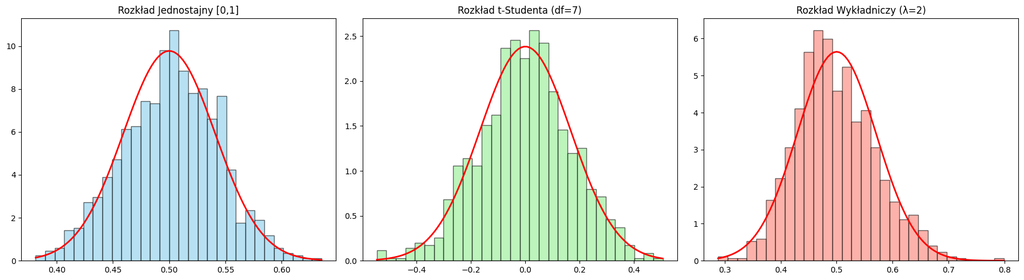

```python
N_zmiennych = 1000
n_wartosci = 50

fig, axes = plt.subplots(1, 3, figsize=(18, 5))
wyniki = []

dane_jednostajny = np.random.uniform(0, 1, size=(n_wartosci, N_zmiennych))
srednie_jednostajny = np.mean(dane_jednostajny, axis=0)

mu_jedn_teor = 0.5
std_jedn_teor = np.sqrt(1 / 12) / np.sqrt(n_wartosci)

axes[0].hist(srednie_jednostajny, bins=30, density=True, alpha=0.6, color='skyblue', edgecolor='black')
x_jedn = np.linspace(min(srednie_jednostajny), max(srednie_jednostajny), 100)
axes[0].plot(x_jedn, norm.pdf(x_jedn, mu_jedn_teor, std_jedn_teor), 'r-', lw=2, label='Teor. rozkład normalny')
axes[0].set_title('Rozkład Jednostajny [0,1]')

wyniki.append({
    'Rozkład': 'Jednostajny [0,1]',
    'Teoretyczna Średnia': mu_jedn_teor,
    'Empiryczna Średnia': np.mean(srednie_jednostajny),
    'Teoretyczne Odch. Std.': std_jedn_teor,
    'Empiryczne Odch. Std.': np.std(srednie_jednostajny, ddof=1)
})

dane_t = np.random.standard_t(df=7, size=(n_wartosci, N_zmiennych))
srednie_t = np.mean(dane_t, axis=0)

mu_t_teor = 0.0

std_t_teor = np.sqrt(7 / 5) / np.sqrt(n_wartosci)

axes[1].hist(srednie_t, bins=30, density=True, alpha=0.6, color='lightgreen', edgecolor='black')
x_t = np.linspace(min(srednie_t), max(srednie_t), 100)
axes[1].plot(x_t, norm.pdf(x_t, mu_t_teor, std_t_teor), 'r-', lw=2, label='Teor. rozkład normalny')
axes[1].set_title('Rozkład t-Studenta (df=7)')

wyniki.append({
    'Rozkład': 't-Studenta (df=7)',
    'Teoretyczna Średnia': mu_t_teor,
    'Empiryczna Średnia': np.mean(srednie_t),
    'Teoretyczne Odch. Std.': std_t_teor,
    'Empiryczne Odch. Std.': np.std(srednie_t, ddof=1)
})

lambda_param = 2
dane_wykl = np.random.exponential(scale=1 / lambda_param, size=(n_wartosci, N_zmiennych))
srednie_wykl = np.mean(dane_wykl, axis=0)

mu_wykl_teor = 1 / lambda_param

std_wykl_teor = (1 / lambda_param) / np.sqrt(n_wartosci)

axes[2].hist(srednie_wykl, bins=30, density=True, alpha=0.6, color='salmon', edgecolor='black')
x_wykl = np.linspace(min(srednie_wykl), max(srednie_wykl), 100)
axes[2].plot(x_wykl, norm.pdf(x_wykl, mu_wykl_teor, std_wykl_teor), 'r-', lw=2, label='Teor. rozkład normalny')
axes[2].set_title('Rozkład Wykładniczy (λ=2)')

wyniki.append({
    'Rozkład': 'Wykładniczy (λ=2)',
    'Teoretyczna Średnia': mu_wykl_teor,
    'Empiryczna Średnia': np.mean(srednie_wykl),
    'Teoretyczne Odch. Std.': std_wykl_teor,
    'Empiryczne Odch. Std.': np.std(srednie_wykl, ddof=1)
})

plt.tight_layout()

df_wyniki = pd.DataFrame(wyniki)
df_wyniki
```

W każdej z trzech symulacji, rozkład średnich po kolumnach przybliża rozkład normalny, co jest zgodne z centralnym twierdzeniem granicznym